# 2020 Full States EV and EC of One Check

## Analyze Marginal Value and MPC over Y(a,eta), Conditional On Kids, Marry, Age, Education

Income is generated by savings and shocks, what are the income levels generated by all the shock and savings points conditional on kids, marital status, age and educational levels. Plot on the Y axis MPC, and plot on the X axis income levels, use colors to first distinguish between different a levels, then use colors to distinguish between different eta levles.

Set Up date, Select Age 38, unmarried, no kids, lower education:

```matlab
% NaN(n_jgrid,n_agrid,n_etagrid,n_educgrid,n_marriedgrid,n_kidsgrid);
% 38 year old, unmarried, no kids, lower educated
% Only Household Head Shock Matters so select up to 'n_eta_H_grid'
mn_total_inc_jemk = total_inc_VFI(20,:,1:mp_params('n_eta_H_grid'),1,1,1);
mn_V_W_gain_check_use = ev20_jaeemk_check2 - ev20_jaeemk_check0;
mn_C_W_gain_check_use = ec20_jaeemk_check2 - ec20_jaeemk_check0;
```

Select Age, Education, Marital, Kids Count:s

```matlab
% Selections
it_age = 21; % +18
it_marital = 1; % 1 = unmarried
it_kids = 1; % 1 = kids is zero
it_educ = 1; % 1 = lower education
% Select: NaN(n_jgrid,n_agrid,n_etagrid,n_educgrid,n_marriedgrid,n_kidsgrid);
mn_C_W_gain_check_jemk = mn_C_W_gain_check_use(it_age, :, 1:mp_params('n_eta_H_grid'), it_educ, it_marital, it_kids);
mn_V_W_gain_check_jemk = mn_V_W_gain_check_use(it_age, :, 1:mp_params('n_eta_H_grid'), it_educ, it_marital, it_kids);
% Reshape, so shock is the first dim, a is the second
mt_total_inc_jemk = permute(mn_total_inc_jemk,[3,2,1]);
mt_C_W_gain_check_jemk = permute(mn_C_W_gain_check_jemk,[3,2,1]);
mt_C_W_gain_check_jemk(mt_C_W_gain_check_jemk<=1e-10) = 1e-10;
mt_V_W_gain_check_jemk = permute(mn_V_W_gain_check_jemk,[3,2,1]);
mt_V_W_gain_check_jemk(mt_V_W_gain_check_jemk<=1e-10) = 1e-10;
% Generate meshed a and shock grid
[mt_eta_H, mt_a] = ndgrid(eta_H_grid(1:mp_params('n_eta_H_grid')), agrid);
```

## Marginal Value Gains, Color as Shock, Conditional on Age, Marital, Kids, and Education

How do shocks and a impact marginal value. First plot one asset level, variation comes only from increasingly higher shocks:

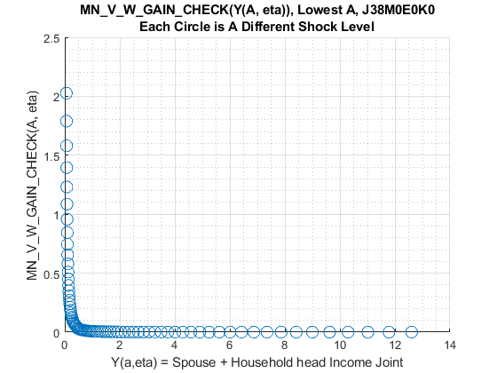

```matlab
figure();
it_a = 1;
scatter((mt_total_inc_jemk(:,it_a)), (mt_V_W_gain_check_jemk(:,it_a)), 100);
title({'MN\_V\_W\_GAIN\_CHECK(Y(A, eta)), Lowest A, J38M0E0K0', ...
    'Each Circle is A Different Shock Level'});
xlabel('Y(a,eta) = Spouse + Household head Income Joint');
ylabel('MN\_V\_W\_GAIN\_CHECK(A, eta)');
grid on;
grid minor;
```

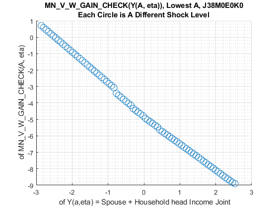

```matlab
figure();
it_shock = 1;
scatter(log(mt_total_inc_jemk(:,it_a)), log(mt_V_W_gain_check_jemk(:,it_a)), 100);
title({'MN\_V\_W\_GAIN\_CHECK(Y(A, eta)), Lowest A, J38M0E0K0', ...
    'Each Circle is A Different Shock Level'});
xlabel(' of Y(a,eta) = Spouse + Household head Income Joint');
ylabel(' of MN\_V\_W\_GAIN\_CHECK(A, eta)');
grid on;
grid minor;
```

Plot all asset levels:

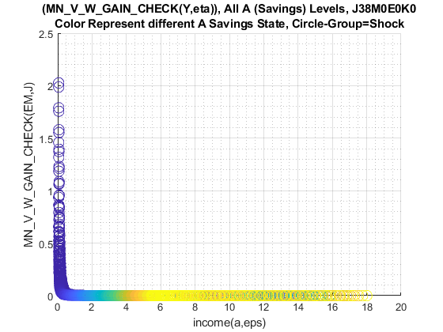

```matlab
figure();
scatter((mt_total_inc_jemk(:)), (mt_V_W_gain_check_jemk(:)), 100, mt_a(:));
title({'(MN\_V\_W\_GAIN\_CHECK(Y,eta)), All A (Savings) Levels, J38M0E0K0', ...
    'Color Represent different A Savings State, Circle-Group=Shock'});
xlabel('income(a,eps)');
ylabel('MN\_V\_W\_GAIN\_CHECK(EM,J)');
grid on;
grid minor;
```

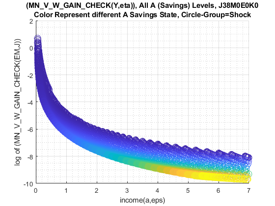

```matlab
figure();
scatter((mt_total_inc_jemk(:)), log(mt_V_W_gain_check_jemk(:)), 100, mt_a(:));
title({'(MN\_V\_W\_GAIN\_CHECK(Y,eta)), All A (Savings) Levels, J38M0E0K0', ...
    'Color Represent different A Savings State, Circle-Group=Shock'});
xlabel('income(a,eps)');
ylabel('log of (MN\_V\_W\_GAIN\_CHECK(EM,J))');
xlim([0,7]);
grid on;
grid minor;
```

## Marginal Consumption Gains, Color as Shock, Conditional on Age, Marital, Kids, and Education

How do shocks and a impact marginal value. First plot one asset level, variation comes only from increasingly higher shocks:

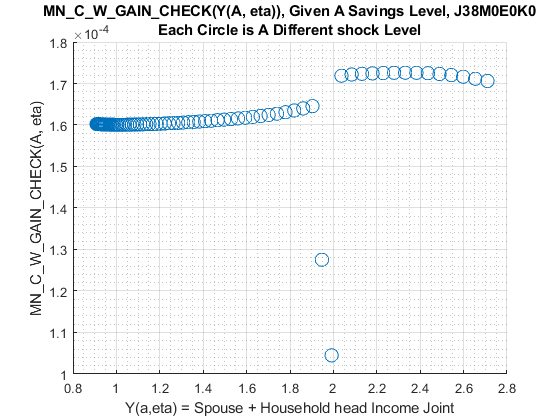

```matlab
figure();
it_a = 50;
scatter(log(mt_total_inc_jemk(:,it_a)), mt_C_W_gain_check_jemk(:,it_a), 100);
title({'MN\_C\_W\_GAIN\_CHECK(Y(A, eta)), Given A Savings Level, J38M0E0K0', ...
    'Each Circle is A Different shock Level'});
xlabel('Y(a,eta) = Spouse + Household head Income Joint');
ylabel('MN\_C\_W\_GAIN\_CHECK(A, eta)');
grid on;
grid minor;
```

Plot all asset levels:

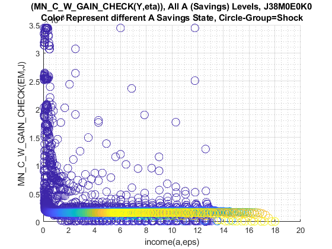

```matlab
figure();
scatter((mt_total_inc_jemk(:)), (mt_C_W_gain_check_jemk(:)), 100, mt_a(:));
title({'(MN\_C\_W\_GAIN\_CHECK(Y,eta)), All A (Savings) Levels, J38M0E0K0', ...
    'Color Represent different A Savings State, Circle-Group=Shock'});
xlabel('income(a,eps)');
ylabel('MN\_C\_W\_GAIN\_CHECK(EM,J)');
grid on;
grid minor;
```

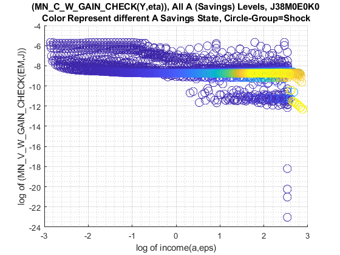

```matlab
figure();
scatter(log(mt_total_inc_jemk(:)), log(mt_C_W_gain_check_jemk(:)), 100, mt_a(:));
title({'(MN\_C\_W\_GAIN\_CHECK(Y,eta)), All A (Savings) Levels, J38M0E0K0', ...
    'Color Represent different A Savings State, Circle-Group=Shock'});
xlabel('log of income(a,eps)');
ylabel('log of (MN\_V\_W\_GAIN\_CHECK(EM,J))');
grid on;
grid minor;
```

## Analyze Kids and Marriage and Age

Aggregating over education, savings, and shocks, what are the differential effects of Marriage and Age.

```matlab
% Generate some Data
mp_support_graph = containers.Map('KeyType', 'char', 'ValueType', 'any');
ar_row_grid = [...
    "k0M0", "K1M0", "K2M0", "K3M0", "K4M0", ...
    "k0M1", "K1M1", "K2M1", "K3M1", "K4M1"];
mp_support_graph('cl_st_xtitle') = {'Age'};
mp_support_graph('st_legend_loc') = 'best';
mp_support_graph('bl_graph_logy') = true; % do not log
mp_support_graph('st_rounding') = '6.2f'; % format shock legend
mp_support_graph('cl_scatter_shapes') = {...
    'o', 'd' ,'s', 'x', '*', ...
    'o', 'd', 's', 'x', '*'};
mp_support_graph('cl_colors') = {...
    'red', 'red', 'red', 'red', 'red'...
    'blue', 'blue', 'blue', 'blue', 'blue'};
```

MEAN(VAL(KM,J)), MEAN(AP(KM,J)), MEAN(C(KM,J))

Tabulate value and policies:

```matlab
% Set
% NaN(n_jgrid,n_agrid,n_etagrid,n_educgrid,n_marriedgrid,n_kidsgrid);
ar_permute = [2,3,4,1,6,5];
% Value Function
st_title = ['MEAN(MN_V_U_GAIN_CHECK(KM,J)), welf_checks=' num2str(welf_checks) ', TR=' num2str(mp_params('TR'))];
tb_az_v = ff_summ_nd_array(st_title, mn_V_U_gain_check, true, ["mean"], 3, 1, cl_mp_datasetdesc, ar_permute);
```

xxx MEAN(MN_V_U_GAIN_CHECK(KM,J)), welf_checks=2, TR=0.0017225 xxxxxxxxxxxxxxxxxxxxxxxxxxx **group** **kids** **marry** **mean_age_18** **mean_age_19** **mean_age_20** **mean_age_21** **mean_age_22** **mean_age_23** **mean_age_24** **mean_age_25** **mean_age_26** **mean_age_27** **mean_age_28** **mean_age_29** **mean_age_30** **mean_age_31** **mean_age_32** **mean_age_33** **mean_age_34** **mean_age_35** **mean_age_36** **mean_age_37** **mean_age_38** **mean_age_39** **mean_age_40** **mean_age_41** **mean_age_42** **mean_age_43** **mean_age_44** **mean_age_45** **mean_age_46** **mean_age_47** **mean_age_48** **mean_age_49** **mean_age_50** **mean_age_51** **mean_age_52** **mean_age_53** **mean_age_54** **mean_age_55** **mean_age_56** **mean_age_57** **mean_age_58** **mean_age_59** **mean_age_60** **mean_age_61** **mean_age_62** **mean_age_63** **mean_age_64** **mean_age_65** **mean_age_66** **mean_age_67** **mean_age_68** **mean_age_69** **mean_age_70** **mean_age_71** **mean_age_72** **mean_age_73** **mean_age_74** **mean_age_75** **mean_age_76** **mean_age_77** **mean_age_78** **mean_age_79** **mean_age_80** **mean_age_81** **mean_age_82** **mean_age_83** **mean_age_84** **mean_age_85** **mean_age_86** **mean_age_87** **mean_age_88** **mean_age_89** **mean_age_90** **mean_age_91** **mean_age_92** **mean_age_93** **mean_age_94** **mean_age_95** **mean_age_96** **mean_age_97** **mean_age_98** **mean_age_99** **mean_age_100** **_____** **____** **_____** **___________** **___________** **___________** **___________** **___________** **___________** **___________** **___________** **___________** **___________** **___________** **___________** **___________** **___________** **___________** **___________** **___________** **___________** **___________** **___________** **___________** **___________** **___________** **___________** **___________** **___________** **___________** **___________** **___________** **___________** **___________** **___________** **___________** **___________** **___________** **___________** **___________** **___________** **___________** **___________** **___________** **___________** **___________** **___________** **___________** **___________** **___________** **___________** **___________** **___________** **___________** **___________** **___________** **___________** **___________** **___________** **___________** **___________** **___________** **___________** **___________** **___________** **___________** **___________** **___________** **___________** **___________** **___________** **___________** **___________** **___________** **___________** **___________** **___________** **___________** **___________** **___________** **___________** **___________** **___________** **___________** **___________** **____________** 1 1 0 0.038527 0.037553 0.036379 0.033145 0.030452 0.028194 0.02628 0.024654 0.023263 0.022063 0.021034 0.020141 0.019365 0.018572 0.017993 0.017482 0.017043 0.016663 0.01633 0.016047 0.015799 …

```matlab
% Consumption Function
st_title = ['MEAN(MN_MPC_U_GAIN_CHECK(KM,J)), welf_checks=' num2str(welf_checks) ', TR=' num2str(mp_params('TR'))];
tb_az_c = ff_summ_nd_array(st_title, mn_MPC_U_gain_share_check, true, ["mean"], 3, 1, cl_mp_datasetdesc, ar_permute);
```

xxx MEAN(MN_MPC_U_GAIN_CHECK(KM,J)), welf_checks=2, TR=0.0017225 xxxxxxxxxxxxxxxxxxxxxxxxxxx **group** **kids** **marry** **mean_age_18** **mean_age_19** **mean_age_20** **mean_age_21** **mean_age_22** **mean_age_23** **mean_age_24** **mean_age_25** **mean_age_26** **mean_age_27** **mean_age_28** **mean_age_29** **mean_age_30** **mean_age_31** **mean_age_32** **mean_age_33** **mean_age_34** **mean_age_35** **mean_age_36** **mean_age_37** **mean_age_38** **mean_age_39** **mean_age_40** **mean_age_41** **mean_age_42** **mean_age_43** **mean_age_44** **mean_age_45** **mean_age_46** **mean_age_47** **mean_age_48** **mean_age_49** **mean_age_50** **mean_age_51** **mean_age_52** **mean_age_53** **mean_age_54** **mean_age_55** **mean_age_56** **mean_age_57** **mean_age_58** **mean_age_59** **mean_age_60** **mean_age_61** **mean_age_62** **mean_age_63** **mean_age_64** **mean_age_65** **mean_age_66** **mean_age_67** **mean_age_68** **mean_age_69** **mean_age_70** **mean_age_71** **mean_age_72** **mean_age_73** **mean_age_74** **mean_age_75** **mean_age_76** **mean_age_77** **mean_age_78** **mean_age_79** **mean_age_80** **mean_age_81** **mean_age_82** **mean_age_83** **mean_age_84** **mean_age_85** **mean_age_86** **mean_age_87** **mean_age_88** **mean_age_89** **mean_age_90** **mean_age_91** **mean_age_92** **mean_age_93** **mean_age_94** **mean_age_95** **mean_age_96** **mean_age_97** **mean_age_98** **mean_age_99** **mean_age_100** **_____** **____** **_____** **___________** **___________** **___________** **___________** **___________** **___________** **___________** **___________** **___________** **___________** **___________** **___________** **___________** **___________** **___________** **___________** **___________** **___________** **___________** **___________** **___________** **___________** **___________** **___________** **___________** **___________** **___________** **___________** **___________** **___________** **___________** **___________** **___________** **___________** **___________** **___________** **___________** **___________** **___________** **___________** **___________** **___________** **___________** **___________** **___________** **___________** **___________** **___________** **___________** **___________** **___________** **___________** **___________** **___________** **___________** **___________** **___________** **___________** **___________** **___________** **___________** **___________** **___________** **___________** **___________** **___________** **___________** **___________** **___________** **___________** **___________** **___________** **___________** **___________** **___________** **___________** **___________** **___________** **___________** **___________** **___________** **___________** **____________** 1 1 0 0.084608 0.090543 0.10335 0.10135 0.099555 0.098243 0.096073 0.094254 0.094087 0.092596 0.091908 0.089934 0.089915 0.087427 0.086446 0.086234 0.084897 0.085062 0.08423 0.083308 0.083229…

Graph Mean Values:

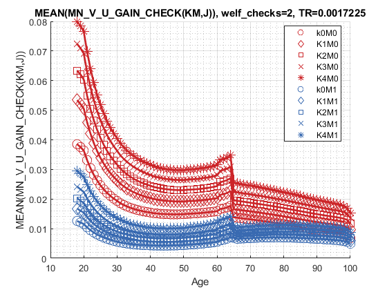

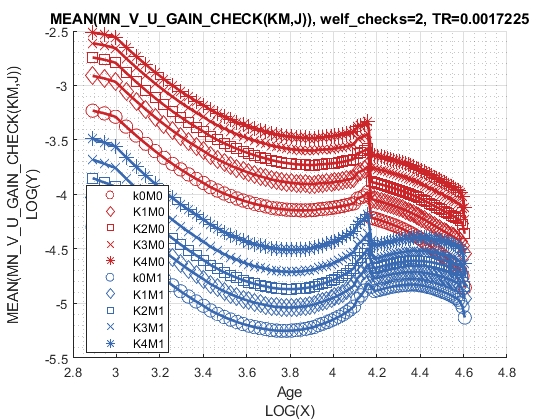

```matlab
st_title = ['MEAN(MN\_V\_U\_GAIN\_CHECK(KM,J)), welf\_checks=' num2str(welf_checks) ', TR=' num2str(mp_params('TR')) ''];
mp_support_graph('cl_st_graph_title') = {st_title};
mp_support_graph('cl_st_ytitle') = {'MEAN(MN\_V\_U\_GAIN\_CHECK(KM,J))'};
ff_graph_grid((tb_az_v{1:end, 4:end}), ar_row_grid, age_grid, mp_support_graph);
```

Graph Mean Consumption (MPC: Share of Check Consumed):

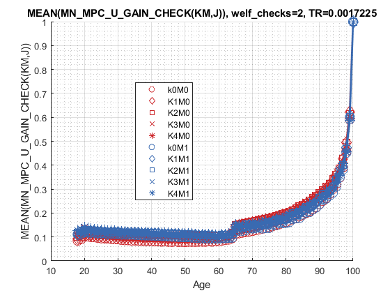

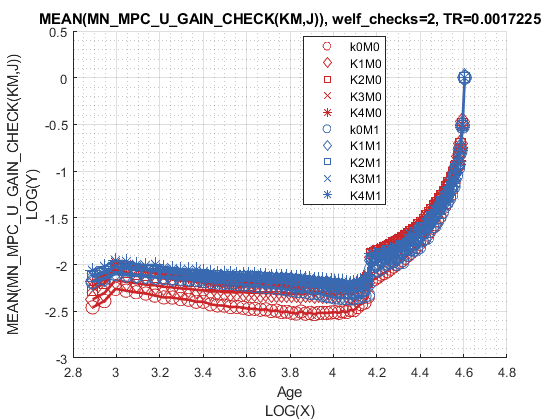

```matlab
st_title = ['MEAN(MN\_MPC\_U\_GAIN\_CHECK(KM,J)), welf\_checks=' num2str(welf_checks) ', TR=' num2str(mp_params('TR')) ''];
mp_support_graph('cl_st_graph_title') = {st_title};
mp_support_graph('cl_st_ytitle') = {'MEAN(MN\_MPC\_U\_GAIN\_CHECK(KM,J))'};
ff_graph_grid((tb_az_c{1:end, 4:end}), ar_row_grid, age_grid, mp_support_graph);
```

## Analyze Education and Marriage

```matlab
% Generate some Data
mp_support_graph = containers.Map('KeyType', 'char', 'ValueType', 'any');
ar_row_grid = ["E0M0", "E1M0", "E0M1", "E1M1"];
mp_support_graph('cl_st_xtitle') = {'Age'};
mp_support_graph('st_legend_loc') = 'best';
mp_support_graph('bl_graph_logy') = true; % do not log
mp_support_graph('st_rounding') = '6.2f'; % format shock legend
mp_support_graph('cl_scatter_shapes') = {'*', 'p', '*','p' };
mp_support_graph('cl_colors') = {'red', 'red', 'blue', 'blue'};
```

MEAN(VAL(EM,J)), MEAN(AP(EM,J)), MEAN(C(EM,J))

Tabulate value and policies:

```matlab
% Set
% NaN(n_jgrid,n_agrid,n_etagrid,n_educgrid,n_marriedgrid,n_kidsgrid);
ar_permute = [2,3,6,1,4,5];
% Value Function
st_title = ['MEAN(MN_V_U_GAIN_CHECK(EM,J)), welf_checks=' num2str(welf_checks) ', TR=' num2str(mp_params('TR'))];
tb_az_v = ff_summ_nd_array(st_title, mn_V_U_gain_check, true, ["mean"], 3, 1, cl_mp_datasetdesc, ar_permute);
```

xxx MEAN(MN_V_U_GAIN_CHECK(EM,J)), welf_checks=2, TR=0.0017225 xxxxxxxxxxxxxxxxxxxxxxxxxxx **group** **edu** **marry** **mean_age_18** **mean_age_19** **mean_age_20** **mean_age_21** **mean_age_22** **mean_age_23** **mean_age_24** **mean_age_25** **mean_age_26** **mean_age_27** **mean_age_28** **mean_age_29** **mean_age_30** **mean_age_31** **mean_age_32** **mean_age_33** **mean_age_34** **mean_age_35** **mean_age_36** **mean_age_37** **mean_age_38** **mean_age_39** **mean_age_40** **mean_age_41** **mean_age_42** **mean_age_43** **mean_age_44** **mean_age_45** **mean_age_46** **mean_age_47** **mean_age_48** **mean_age_49** **mean_age_50** **mean_age_51** **mean_age_52** **mean_age_53** **mean_age_54** **mean_age_55** **mean_age_56** **mean_age_57** **mean_age_58** **mean_age_59** **mean_age_60** **mean_age_61** **mean_age_62** **mean_age_63** **mean_age_64** **mean_age_65** **mean_age_66** **mean_age_67** **mean_age_68** **mean_age_69** **mean_age_70** **mean_age_71** **mean_age_72** **mean_age_73** **mean_age_74** **mean_age_75** **mean_age_76** **mean_age_77** **mean_age_78** **mean_age_79** **mean_age_80** **mean_age_81** **mean_age_82** **mean_age_83** **mean_age_84** **mean_age_85** **mean_age_86** **mean_age_87** **mean_age_88** **mean_age_89** **mean_age_90** **mean_age_91** **mean_age_92** **mean_age_93** **mean_age_94** **mean_age_95** **mean_age_96** **mean_age_97** **mean_age_98** **mean_age_99** **mean_age_100** **_____** **___** **_____** **___________** **___________** **___________** **___________** **___________** **___________** **___________** **___________** **___________** **___________** **___________** **___________** **___________** **___________** **___________** **___________** **___________** **___________** **___________** **___________** **___________** **___________** **___________** **___________** **___________** **___________** **___________** **___________** **___________** **___________** **___________** **___________** **___________** **___________** **___________** **___________** **___________** **___________** **___________** **___________** **___________** **___________** **___________** **___________** **___________** **___________** **___________** **___________** **___________** **___________** **___________** **___________** **___________** **___________** **___________** **___________** **___________** **___________** **___________** **___________** **___________** **___________** **___________** **___________** **___________** **___________** **___________** **___________** **___________** **___________** **___________** **___________** **___________** **___________** **___________** **___________** **___________** **___________** **___________** **___________** **___________** **___________** **____________** 1 0 0 0.062745 0.06175 0.060482 0.056976 0.053863 0.051102 0.048627 0.046423 0.04445 0.042664 0.041069 0.039634 0.03833 0.036913 0.035869 0.034914 0.034065 0.033297 0.032608 0.031988 0.031418 0.0…

```matlab
% Consumption
st_title = ['MEAN(MN_MPC_U_GAIN_CHECK(EM,J)), welf_checks=' num2str(welf_checks) ', TR=' num2str(mp_params('TR'))];
tb_az_c = ff_summ_nd_array(st_title, mn_MPC_U_gain_share_check, true, ["mean"], 3, 1, cl_mp_datasetdesc, ar_permute);
```

xxx MEAN(MN_MPC_U_GAIN_CHECK(EM,J)), welf_checks=2, TR=0.0017225 xxxxxxxxxxxxxxxxxxxxxxxxxxx **group** **edu** **marry** **mean_age_18** **mean_age_19** **mean_age_20** **mean_age_21** **mean_age_22** **mean_age_23** **mean_age_24** **mean_age_25** **mean_age_26** **mean_age_27** **mean_age_28** **mean_age_29** **mean_age_30** **mean_age_31** **mean_age_32** **mean_age_33** **mean_age_34** **mean_age_35** **mean_age_36** **mean_age_37** **mean_age_38** **mean_age_39** **mean_age_40** **mean_age_41** **mean_age_42** **mean_age_43** **mean_age_44** **mean_age_45** **mean_age_46** **mean_age_47** **mean_age_48** **mean_age_49** **mean_age_50** **mean_age_51** **mean_age_52** **mean_age_53** **mean_age_54** **mean_age_55** **mean_age_56** **mean_age_57** **mean_age_58** **mean_age_59** **mean_age_60** **mean_age_61** **mean_age_62** **mean_age_63** **mean_age_64** **mean_age_65** **mean_age_66** **mean_age_67** **mean_age_68** **mean_age_69** **mean_age_70** **mean_age_71** **mean_age_72** **mean_age_73** **mean_age_74** **mean_age_75** **mean_age_76** **mean_age_77** **mean_age_78** **mean_age_79** **mean_age_80** **mean_age_81** **mean_age_82** **mean_age_83** **mean_age_84** **mean_age_85** **mean_age_86** **mean_age_87** **mean_age_88** **mean_age_89** **mean_age_90** **mean_age_91** **mean_age_92** **mean_age_93** **mean_age_94** **mean_age_95** **mean_age_96** **mean_age_97** **mean_age_98** **mean_age_99** **mean_age_100** **_____** **___** **_____** **___________** **___________** **___________** **___________** **___________** **___________** **___________** **___________** **___________** **___________** **___________** **___________** **___________** **___________** **___________** **___________** **___________** **___________** **___________** **___________** **___________** **___________** **___________** **___________** **___________** **___________** **___________** **___________** **___________** **___________** **___________** **___________** **___________** **___________** **___________** **___________** **___________** **___________** **___________** **___________** **___________** **___________** **___________** **___________** **___________** **___________** **___________** **___________** **___________** **___________** **___________** **___________** **___________** **___________** **___________** **___________** **___________** **___________** **___________** **___________** **___________** **___________** **___________** **___________** **___________** **___________** **___________** **___________** **___________** **___________** **___________** **___________** **___________** **___________** **___________** **___________** **___________** **___________** **___________** **___________** **___________** **___________** **____________** 1 0 0 0.091431 0.09559 0.10516 0.10437 0.10421 0.10418 0.10369 0.10329 0.10346 0.10274 0.10354 0.103 0.10318 0.10191 0.10175 0.10212 0.10173 0.10165 0.10207 0.10211 0.10139 0.10145 0.10197 0.10…

Graph Mean Values:

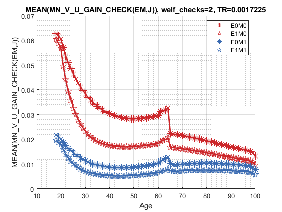

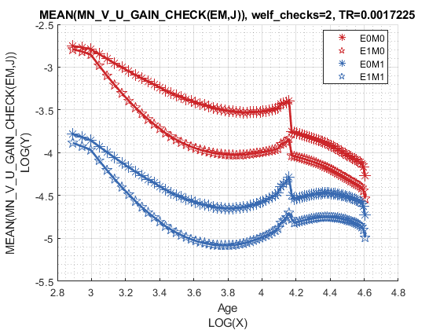

```matlab
st_title = ['MEAN(MN\_V\_U\_GAIN\_CHECK(EM,J)), welf\_checks=' num2str(welf_checks) ', TR=' num2str(mp_params('TR')) ''];
mp_support_graph('cl_st_graph_title') = {st_title};
mp_support_graph('cl_st_ytitle') = {'MEAN(MN\_V\_U\_GAIN\_CHECK(EM,J))'};
ff_graph_grid((tb_az_v{1:end, 4:end}), ar_row_grid, age_grid, mp_support_graph);
```

Graph Mean Consumption (MPC: Share of Check Consumed):

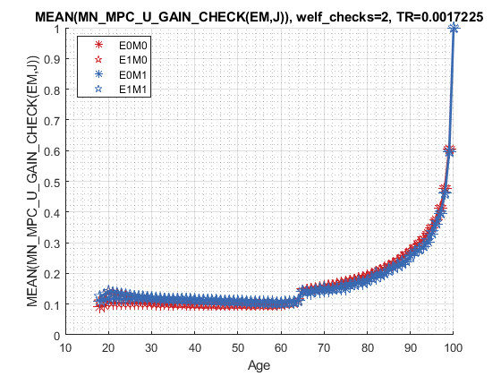

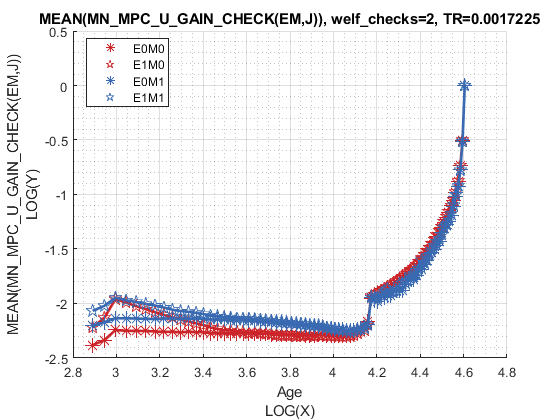

```matlab
st_title = ['MEAN(MN\_MPC\_U\_GAIN\_CHECK(EM,J)), welf\_checks=' num2str(welf_checks) ', TR=' num2str(mp_params('TR')) ''];
mp_support_graph('cl_st_graph_title') = {st_title};
mp_support_graph('cl_st_ytitle') = {'MEAN(MN\_MPC\_U\_GAIN\_CHECK(EM,J))'};
ff_graph_grid((tb_az_c{1:end, 4:end}), ar_row_grid, age_grid, mp_support_graph);
```